# Statistical learning: unsupervised learning

MACS 30100 - Perspectives on Computational Modeling

# Objectives

- Distinguish unsupervised learning from supervised learning
- Demonstrate how to estimate and interpret $K$-means clustering
- Demonstrate how to estimate and interpret hierarchical clustering
- Define key terms for unsupervised text analysis
- Explain the purpose of dimension reduction techniques
- Demonstrate how to estimate and interpret principal components analysis
- Implement latent semantic analysis using text data
- Introduce Latent Dirchlet allocation and apply it to example data

```r
library(tidyverse)
library(forcats)
library(broom)
library(modelr)
library(stringr)
library(ISLR)
library(titanic)
library(rcfss)
library(grid)
library(gridExtra)
library(ggdendro)
library(tidytext)
library(tm)
library(topicmodels)

options(digits = 3)
set.seed(1234)
theme_set(theme_minimal())
```

# Unsupervised learning

**Supervised learning** methods are used in situations where you have a set of $p$ predictors $X_1, X_2, \dots, X_p$ measured on $n$ observations and you want to explain or predict a response $Y$ also measured on those $n$ observations. **Unsupervised learning** methods differ in that you have a set of $p$ predictors $X_1, X_2, \dots, X_p$ measured on $n$ observations, *but you do not have an associated response variable $Y$*. Instead you want to explore the structure and grouping of the observations. Typically unsupervised learning is a more **exploratory process** because you have no end result you are specifically looking for, and you have no measuring stick to decide if you have the “right” results. At least with supervised learning, you can assess the accuracy or fit of the model and decide how well it performs or compare it to other models. Techinques such as cross-validation and resampling methods can be used to ensure we are not overfitting the training data. But with unsupervised learning this is impossible, because you don’t know the “true” answer.

There are a wide range of unsupervised learning methods, and their use is governed by the type of research question you have. Here we will examine three types of methods: clustering, dimension reduction, and topic modeling.

# Clustering methods

**Clustering** refers to a set of techniques for finding subgroups within a dataset, called **clusters**. The goal is to partition the dataset into similar and distinct groups so that observations in each group are similar to one another, while each group is distinctive and dissimilar to the other groups.

## $K$-means clustering

$K$-means clustering is one approach to identifying distinct clusters within data. First we specify the number of $K$ clusters we want to estimate in the data, then assign each observation to precisely one of those $K$ clusters.

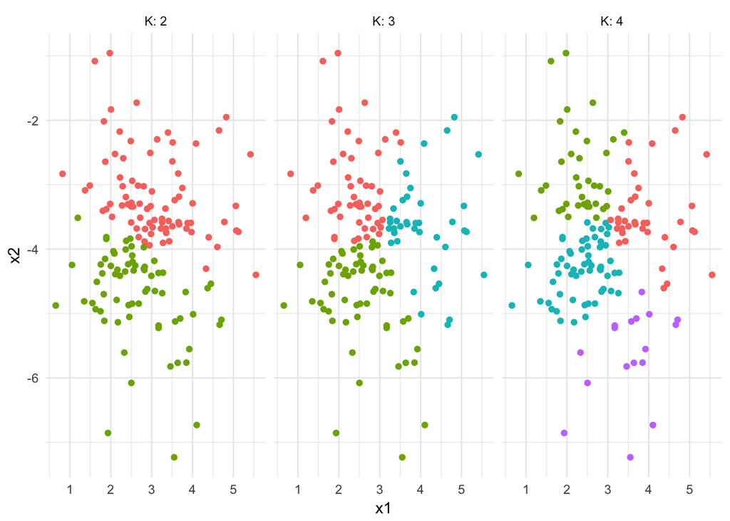

```r
# generate data
x <- data_frame(x1 = rnorm(150) + 3,
                x2 = rnorm(150) - 4)

# estimate k clusters
x.out <- x %>%
  mutate(k2 = kmeans(x, 2, nstart = 20)$cluster,
         k3 = kmeans(x, 3, nstart = 20)$cluster,
         k4 = kmeans(x, 4, nstart = 20)$cluster)

# plot clusters
x.out %>%
  gather(K, pred, k2:k4) %>%
  mutate(K = parse_numeric(K),
         pred = factor(pred)) %>%
  ggplot(aes(x1, x2, color = pred)) +
  facet_grid(. ~ K, labeller = label_both) +
  geom_point() +
  theme(legend.position = "none")
```

Let $C_1, C_2, \dots, C_K$ denote sets containing the indicies of the observations in each cluster. $K$-means clustering defines a good cluster as one for which within-cluster variation is as small as possible. So we want to minimize the within-cluster variation defined by some function $W(C_K)$ that identifies variation:

$$\min_{C_1, C_2, \dots, C_K} \left\{ \sum_{k = 1}^K W(C_k) \right\}$$

so that the overall amount of within-cluster variation across all the clusters is as small as possible. We can define within-cluster variation in several different ways, but a standard approach uses **squared Euclidean distance**:

$$W(C_k) = \frac{1}{|C_k|} \sum_{i,i' \in C_k} \sum_{j = 1}^p (x_{ij} - x_{i'j})^2$$

where the within-cluster variation is the sum of all of the pairwise squared Euclidean distances between the observations in the $k$th cluster, divided by the number of observations in the $k$th cluster. Unfortunately we cannot evaluate every possible cluster combination because there are almost $K^n$ ways to partition $n$ observations into $K$ clusters. Instead, we will settle for a **good enough** approach; that is, rather than finding the global optimum for the optimization problem we will instead estimate the local optimum.

To do this we employ an iterative process. First we randomly assign each observation to one of the $K$ clusters. This will be the initial cluster assignment for each observation. Then we iterate over the cluster assignments:

1. For each of the $K$ clusters, compute the cluster **centroid**, or the vector of $p$ feature means for the observations in the $k$th cluster.
2. Assign each observation to the cluster whose centroid is closest as defined by Euclidean distance.

Each time we do this observations will move around and join different clusters because the initial assignments were made entirely at random. As we iterate over this process, the cluster assignments will become more stable and eventually stop entirely. This is when we reach the local optimum. Since the local optimum is based on the initial (random) assignments, we run this algorithm multiple times from different random starting configurations and select the best solution (the one with the lowest total within-cluster variation).

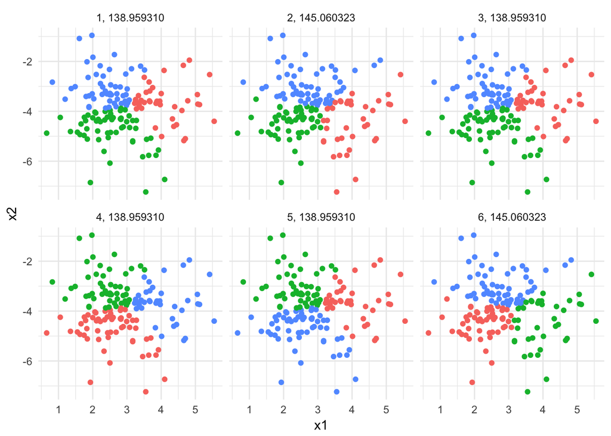

```r
kmean.out <- rerun(6, kmeans(x, 3, nstart = 1))

kmean.out %>%
  map_df(~ as_tibble(.$cluster), .id = "id") %>%
  bind_cols(bind_rows(x,x,x,x,x,x)) %>%
  mutate(withinss = rep(map_chr(kmean.out, ~ .$tot.withinss), each = nrow(x)),
         value = factor(value)) %>%
  ggplot(aes(x1, x2, color = value)) +
  facet_wrap(~ id + withinss, ncol = 3, labeller = label_wrap_gen(multi_line = FALSE)) +
  geom_point() +
  theme(legend.position = "none")
```

## Hierarchical clustering

A drawback to $K$-means clustering is that it requires you to specify in advance the number of clusters in the data. Since this is unsupervised learning, you don’t really know the actual number of clusters. Depending on the major features of the data, different values of $K$ could produce equally meaningful results. Imagine if your data contains observations on individuals, split between males and females as well as split between Americans, Canadians, and South Africans. $K=2$ would potentially cluster the observations based on gender, whereas $K=3$ could cluster based on nationality. Which is “right”? Well, both of them. It depends on the features of the data in which you are most interested.

**Hierarchical clustering** is an alternative approach that does not require us to fix the number of clusters *a priori*. It also produces a visual interpretation of the clusters using tree-based representations called **dendrograms**. Here let’s review how to interpret dendrograms generated from **bottom-up** clustering.

## Interpreting dendrograms

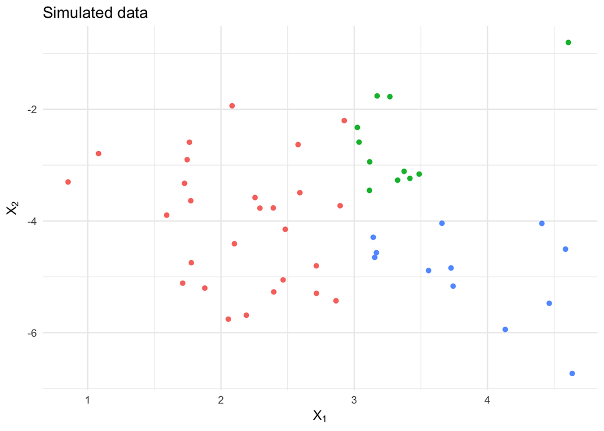

```r
# generate data
x <- data_frame(x1 = rnorm(50) + 3,
                x2 = rnorm(50) - 4,
                y = ifelse(x1 < 3, "1",
                           ifelse(x2 > -4, "2", "3")))

ggplot(x, aes(x1, x2, color = y)) +
  geom_point() +
  labs(title = "Simulated data",
       x = expression(X[1]),
       y = expression(X[2])) +
  theme(legend.position = "none")
```

Suppose that we observe the data without class labels and want to perform hierarchical clustering on the data. The result is plotted below.

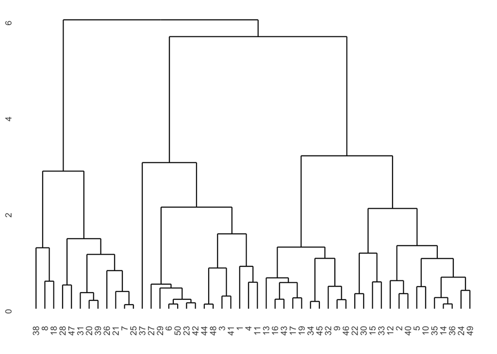

```r
# estimate hierarchical cluster
hc.complete <- hclust(dist(x), method = "complete")

# plot
ggdendrogram(hc.complete)
```

Like with decision trees, we have **leafs** and **branches**. Each leaf is labeled with the observation id number. Rather than reading the dendrogram from the top-down, we read it from the bottom-up. Each observation is represented by a leaf. As we move up the tree, leafs **fuse** into branches. These are observations that are similar to one another, similarity generally being defined by Euclidean distance. Observations that fuse together near the bottom of the tree are generally similar to one another, whereas observations that fuse near the top of the tree are dissimilar. The height on the graph where the fusion occurs defines how similar or dissimilar any two observations are. The larger the value, the more dissimilar they are. Rather than paying attention to the proximity of observations along the horizontal axis, we should instead focus on the location of observations relative to the vertical axis.

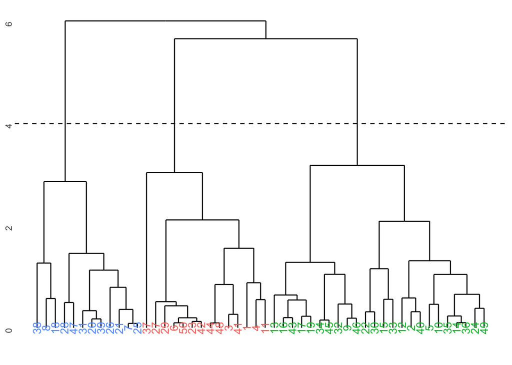

```r
h <- 4
# extract dendro data
hcdata <- dendro_data(hc.complete)
hclabs <- label(hcdata) %>%
  left_join(data_frame(label = as.factor(seq.int(nrow(x))),
                       cl = as.factor(cutree(hc.complete, h = h))))

# plot dendrogram
ggdendrogram(hc.complete, labels = FALSE) +
  geom_text(data = hclabs,
            aes(label = label, x = x, y = 0, color = cl),
            vjust = .5, angle = 90) +
  geom_hline(yintercept = h, linetype = 2) +
  theme(axis.text.x = element_blank(),
        legend.position = "none")
```

Alternatively we could split it lower, for instance at 3:

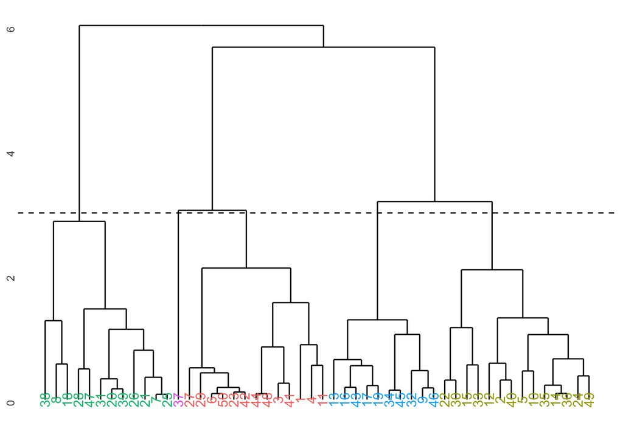

```r
h <- 3
# extract dendro data
hcdata <- dendro_data(hc.complete)
hclabs <- label(hcdata) %>%
  left_join(data_frame(label = as.factor(seq.int(nrow(x))),
                       cl = as.factor(cutree(hc.complete, h = h))))

# plot dendrogram
ggdendrogram(hc.complete, labels = FALSE) +
  geom_text(data = hclabs,
            aes(label = label, x = x, y = 0, color = cl),
            vjust = .5, angle = 90) +
  geom_hline(yintercept = h, linetype = 2) +
  theme(axis.text.x = element_blank(),
        legend.position = "none")
```

Generating a larger number of clusters. Determining the optimal number of clusters is generally left to the discretion of the researcher based on the height of the fusions and desired number of clusters. Again, this is unsupervised learning **so there is no single correct number of clusters**.

## Estimating hierarchical clusters

This process is continued until there is only a single cluster remaining. The only complication is how to measure dissimilarities between clusters once they contain more than one observation. Previously we used pairwise dissimilarities of the observations, but how do we proceed with multiple observations? There are four major approaches to defining dissimilarity between clusters, also called **linkage**:

1. **Complete** - compute all pairwise dissimilarities between observations in cluster A and cluster B and record the largest of these dissimilarities.
2. **Single** - compute all pairwise dissimilarities between observations in cluster A and cluster B and record the smallest of these dissimilarities.
3. **Average** - compute all pairwise dissimilarities between observations in cluster A and cluster B and record the average of these dissimilarities.
4. **Centroid** - compute the dissimilarity between the centroid (a mean vector of length $p$) for cluster A and cluster B.

Each linkage approach leads to different hierarchical clusters:

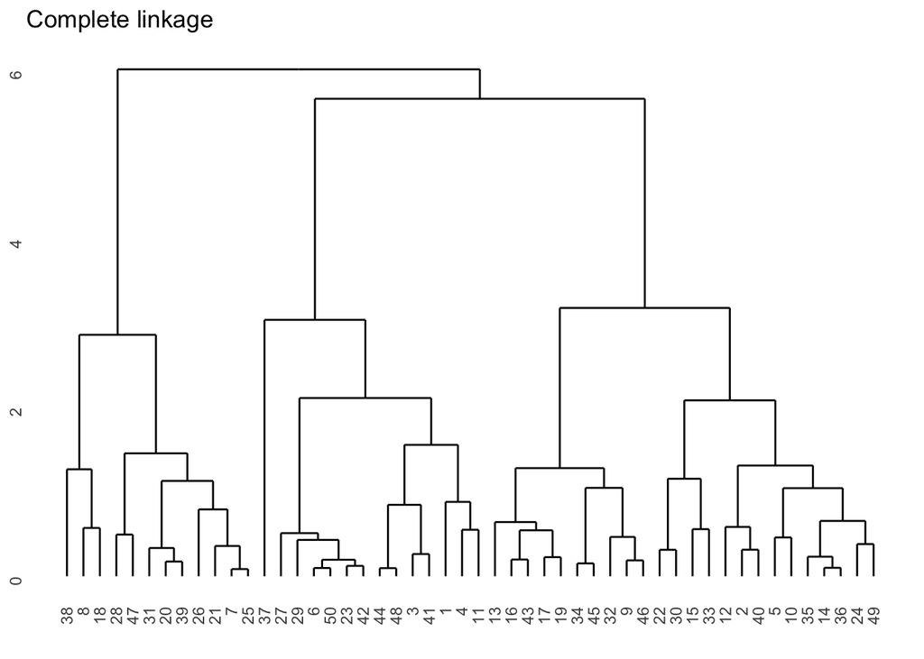

```r
hc.complete <- hclust(dist(x), method = "complete")
hc.single <- hclust(dist(x), method = "single")
hc.average <- hclust(dist(x), method = "average")

# plot
ggdendrogram(hc.complete) +
  labs(title = "Complete linkage")
```

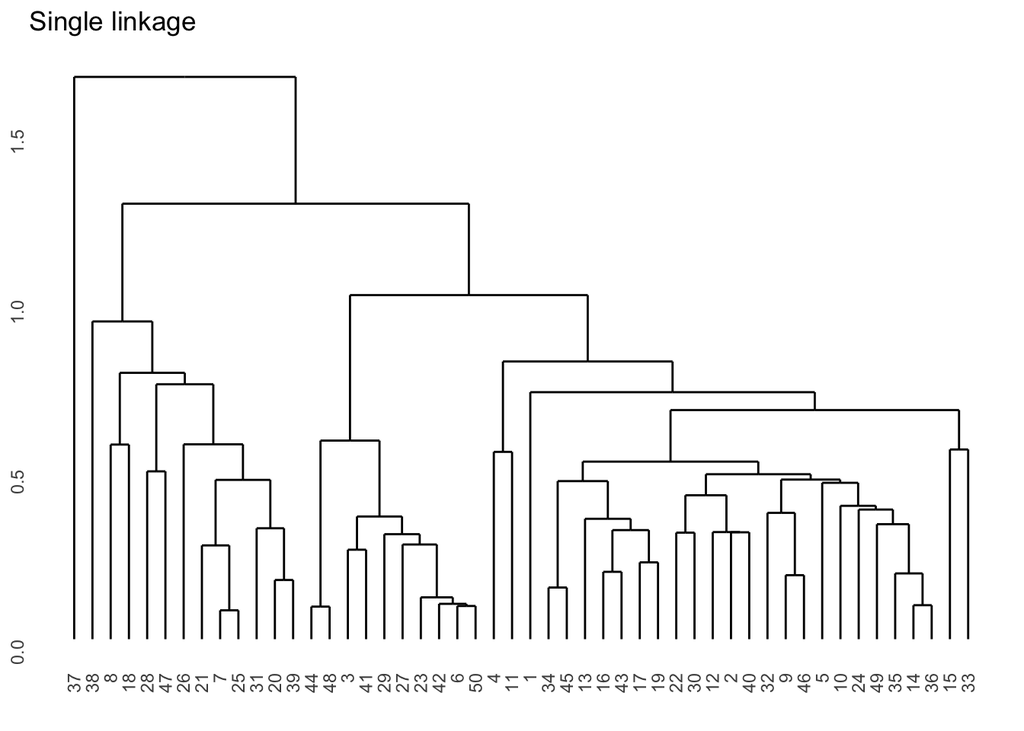

```r
ggdendrogram(hc.single) +
  labs(title = "Single linkage")
```

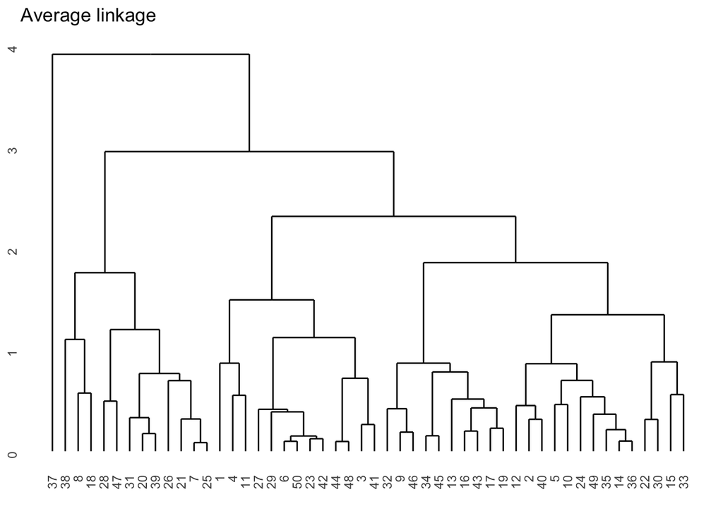

```r
ggdendrogram(hc.average) +
  labs(title = "Average linkage")
```

# Dimension reduction

Another possible application of unsupervised learning is to reduce the number of dimensions in a dataset. There are a couple reasons you might do this:

1. You want to visualize the data but you have a lot of variables. You could generate something like a scatterplot matrix, but once you have more than a handful of variables even these become difficult to interpret.
2. You want to use the variables in a supervised learning framework, but reduce the total number of predictors to make the estimation more efficient.

In either case, the goal is to reduce the dimensionality of the data by identifying a smaller number of representative variables that collectively explain most of the variability in the original dataset. There are several methods available for performing such a task. First we will examine an example of applying dimension reduction techniques to summarize roll-call voting in the United States

## Application: DW-NOMINATE

In the 1990s, dimension reduction techniques revolutionized the study of U.S. legislative politics. Measuring the ideology of legislators prior to this point was difficult because there was no method for locating legislators along an ideological spectrum (liberal-conservative) in a manner that allowed comparisons over time. That is, how liberal was a Democrat in 1870 compared to a Democrat in 1995? Additionally, supposed you wanted to predict how a legislator would vote on a given bill. Roll-call votes record individual legislator behavior, so you could use past votes to predict future ones. But there have been tens of thousands of recorded votes over the course of the U.S. Congress. Even in a given term of Congress, the Senate may cast hundreds of recorded votes. But there are only 100 senators (at present), and you cannot estimate a regression model when your number of predictors $p$ is larger than your number of observations $n$. We need some method for reducing the dimensionality of this data to a handful of variables which explain as much of the variation in roll-call voting as possible.

**Multidimensional scaling techniques** can be used to perform this feat. The technical details of this specific application are beyond the scope of this class, but Keith Poole and Howard Rosenthal developed a specific procedure called [NOMINATE](http://voteview.org/) to reduce the dimensionality of the data. Rather than using $p$ predictors to explain or predict individual legislator’s roll-call votes, where $p$ is the total number of roll-call votes in the recorded history of the U.S. Congress, Poole and Rosenthal examined the similarity of legislators’ votes in a given session of Congress and over time to identify two major dimensions to roll-call voting in the U.S. Congress. That is, roll-call votes in Congress can generally be explained by two variables that can be estimated for every past and present member of Congress. The two dimensions do not have any inherent substantive interpretation, but by graphically examining the two dimensions, it becomes clear that they represent two specific factors in legislative voting:

1. First dimension - political ideology. This dimension appears to represent political ideology on the liberal-conservative spectrum. Positive values on this dimension refer to increasingly conservative voting patterns, and negative values refer to increasingly liberal voting patterns.
2. Second dimension - “issue of the day”. This dimension appears to pick up on attitudes that are salient at different points in the nation’s history. They could be regional differences (Southern vs. non-Southern states), or attitudes towards specific policy issues (i.e. slavery).

This data can be used for a wide range of research questions. For example, we could use it to assess the degree of polarization in the U.S. Congress over time:

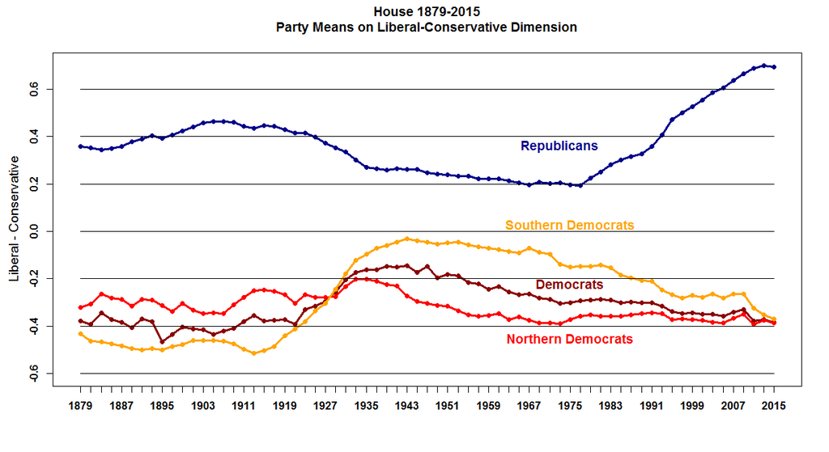

[Voteview.org](http://voteview.org/political_polarization_2015.htm)

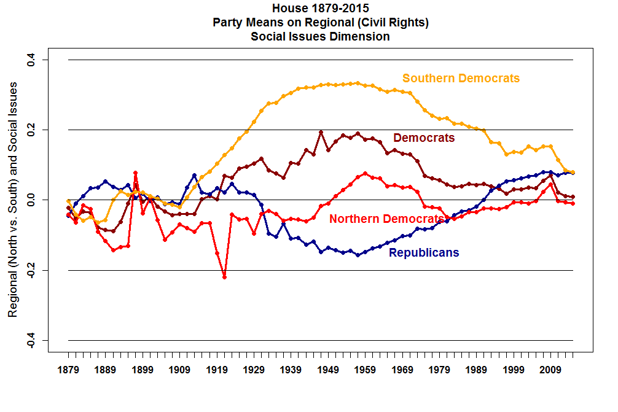

[Voteview.org](http://voteview.org/political_polarization_2015.htm)

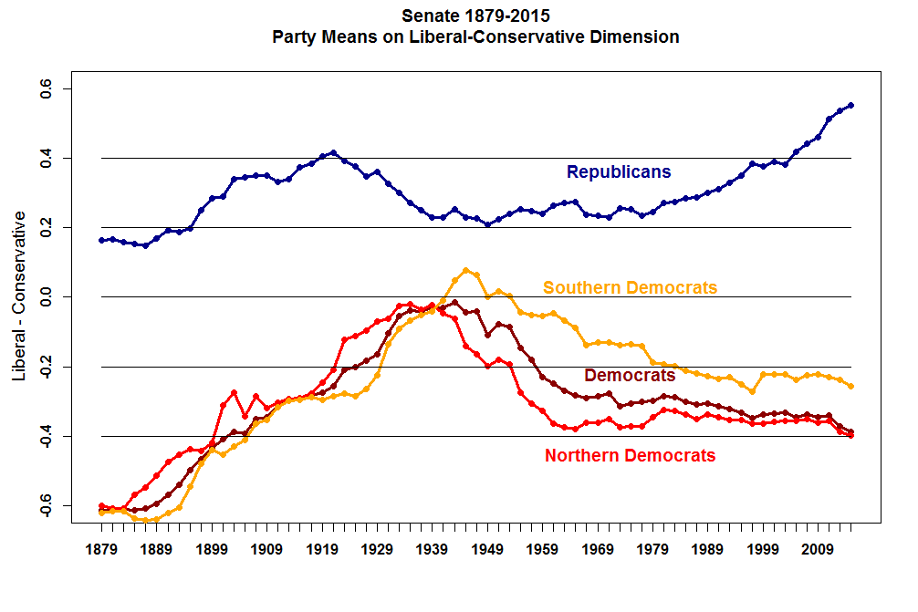

[Voteview.org](http://voteview.org/political_polarization_2015.htm)

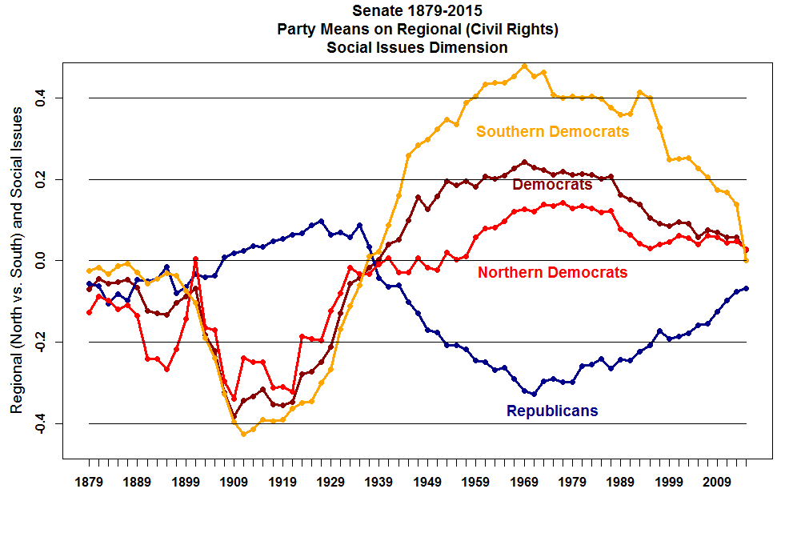

[Voteview.org](http://voteview.org/political_polarization_2015.htm)